# Session 2: Homework 1

- Examine the relationship between `gross` and `budget`. Produce a scatterplot and write one sentence discussing whether budget is likely to be a good predictor of how much money a movie will make at the box office.

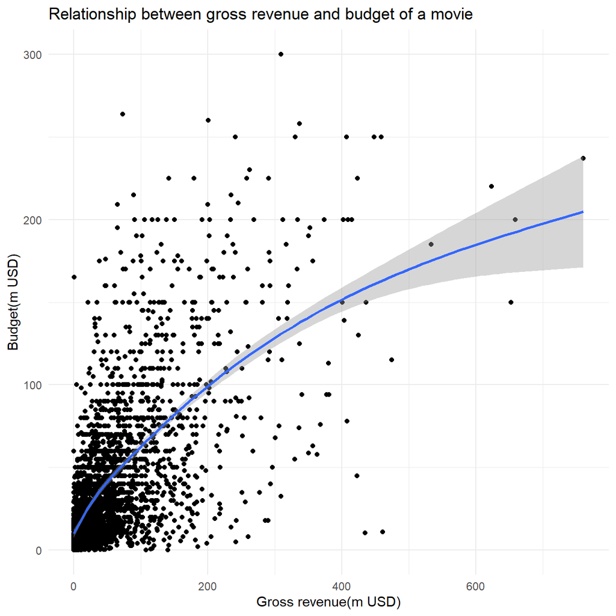

```r
#Let's plot a scatterplot with movies data, we will map the gross earnings on the x axis and budget on the y axis, both are in millions
ggplot(data = movies, mapping = aes(x=gross/1000000, y=budget/1000000)) +
      geom_point() +
#Then we draw a line of best fit to better understand the trend
      geom_smooth() +
#Then we add titles
      labs(title="Relationship between gross revenue and budget of a movie", x="Gross revenue(m USD)", y="Budget(m USD)")+
#And choose theme minimal for plot styling
      theme_minimal()
```

- Examine the relationship between `gross` and `rating`. Produce a scatterplot, faceted by `genre` and discuss whether IMDB ratings are likely to be a good predictor of how much money a movie will make at the box office. Is there anything strange in this dataset?

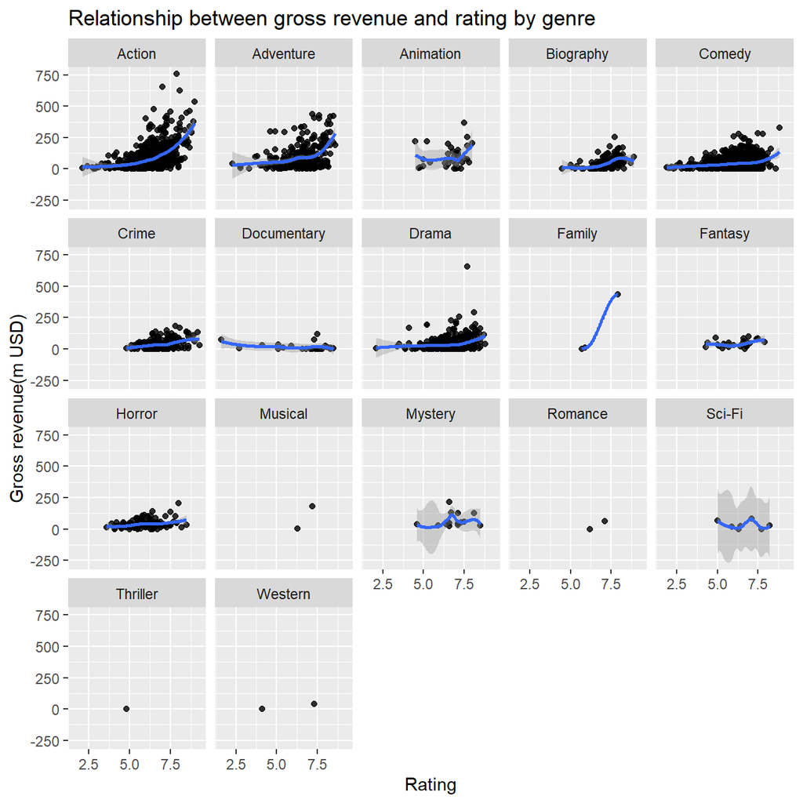

```r
#Let's produce a scatterplot with movies data, we will map IMDb ratings on the x axis and gross earnings in millions on the y axis.
ggplot(data = movies, mapping = aes(x=rating, y=gross/1000000)) +
      geom_point(alpha=0.8) +
      #Then will produce a plot for each genre
      facet_wrap(~genre) +
      #Then a fitting line using the geom_smooth function
      geom_smooth() +
      #Add title for plot and axis
      labs(title="Relationship between gross revenue and rating by genre", x="Rating", y="Gross revenue(m USD)")
```

Adventure and Action movies, and even Animation that have high IMD rating, are actually showing a strong relationship between rating and gross revenue, but we need to account that it is only for mentioned genres. In others, such as Horror, Biography, Documentary, Fantasy, the line is basically flat, showing minimal to no relationship between rating. Overall, IMB ranlking are not a good predictor of a gross revenues, but for some genres they actually work.

# 3 Returns of financial stocks

> You may find useful the material on [finance data sources](https://mfa2022.netlify.app/reference/finance_data/).

We will use the `tidyquant` package to download historical data of stock prices, calculate returns, and examine the distribution of returns.

We must first identify which stocks we want to download data for, and for this we must know their ticker symbol; Apple is known as AAPL, Microsoft as MSFT, McDonald’s as MCD, etc. The file `nyse.csv` contains 508 stocks listed on the NYSE, their ticker `symbol`, `name`, the IPO (Initial Public Offering) year, and the sector and industry the company is in.

```r
nyse <- read_csv(here::here("data","nyse.csv"))
```

Based on this dataset, create a table and a bar plot that shows the number of companies per sector, in descending order

```
## # A tibble: 12 x 2
## # Groups:   sector [12]
##    sector                    n
##    <chr>                 <int>
##  1 Finance                  97
##  2 Consumer Services        79
##  3 Public Utilities         60
##  4 Capital Goods            45
##  5 Health Care              45
##  6 Energy                   42
##  7 Technology               40
##  8 Basic Industries         39
##  9 Consumer Non-Durables    31
## 10 Miscellaneous            12
## 11 Transportation           10
## 12 Consumer Durables         8
```

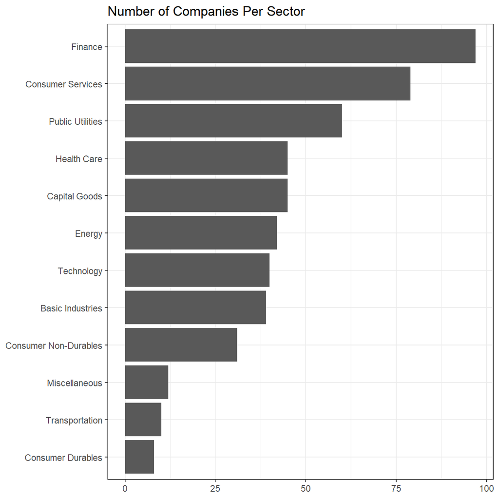

```r
# create table
nyse %>%
  # first group the dataset by sector
  group_by(sector) %>%
  # then use count function to get the number of companies per sector, setting argument sort be TRUE to display it in descending order
  count(sort=TRUE) %>%
  print() %>%

  # create a ggplot object and set number of companies as x-axis and the reorderd dextor as y-axis
  ggplot(aes(x = n, y = fct_reorder(sector, n))) +
  geom_bar(stat='identity')+
  theme_bw()+
  labs(
    title = "Number of Companies Per Sector",
    x = NULL,
    y = NULL
  )+
  NULL
```

Next, let’s choose the [Dow Jones Industrial Aveareg (DJIA)](https://en.wikipedia.org/wiki/Dow_Jones_Industrial_Average) stocks and their ticker symbols and download some data. Besides the thirty stocks that make up the DJIA, we will also add `SPY` which is an SP500 ETF (Exchange Traded Fund). The following code

```r
djia_url <- "https://en.wikipedia.org/wiki/Dow_Jones_Industrial_Average"


#get tables that exist on URL
tables <- djia_url %>%
  read_html() %>%
  html_nodes(css="table")


# parse HTML tables into a dataframe called djia.
# Use purr::map() to create a list of all tables in URL
djia <- map(tables, . %>%
               html_table(fill=TRUE)%>%
               clean_names())


# constituents
table1 <- djia[[2]] %>% # the second table on the page contains the ticker symbols
  mutate(date_added = ymd(date_added),

         # if a stock is listed on NYSE, its symbol is, e.g., NYSE: MMM
         # We will get prices from yahoo finance which requires just the ticker

         # if symbol contains "NYSE*", the * being a wildcard
         # then we jsut drop the first 6 characters in that string
         ticker = ifelse(str_detect(symbol, "NYSE*"),
                          str_sub(symbol,7,11),
                          symbol)
         )

# we need a vector of strings with just the 30 tickers + SPY
tickers <- table1 %>%
  select(ticker) %>%
  pull() %>% # pull() gets them as a sting of characters
  c("SPY") # and lets us add SPY, the SP500 ETF
```

```r
# Notice the cache=TRUE argument in the chunk options. Because getting data is time consuming, # cache=TRUE means that once it downloads data, the chunk will not run again next time you knit your Rmd

myStocks <- tickers %>%
  tq_get(get  = "stock.prices",
         from = "2000-01-01",
         to   = Sys.Date()) %>% # Sys.Date() returns today's price
  group_by(symbol)

glimpse(myStocks) # examine the structure of the resulting data frame
```

```
## Rows: 161,491
## Columns: 8
## Groups: symbol [31]
## $ symbol   <chr> "MMM", "MMM", "MMM", "MMM", "MMM", "MMM", "MMM", "MMM", "MMM"~
## $ date     <date> 2000-01-03, 2000-01-04, 2000-01-05, 2000-01-06, 2000-01-07, ~
## $ open     <dbl> 48.0, 46.4, 45.6, 47.2, 50.6, 50.2, 50.4, 51.0, 50.7, 50.4, 4~
## $ high     <dbl> 48.2, 47.4, 48.1, 51.2, 51.9, 51.8, 51.2, 51.8, 50.9, 50.5, 4~
## $ low      <dbl> 47.0, 45.3, 45.6, 47.2, 50.0, 50.0, 50.2, 50.4, 50.2, 49.5, 4~
## $ close    <dbl> 47.2, 45.3, 46.6, 50.4, 51.4, 51.1, 50.2, 50.4, 50.4, 49.7, 4~
## $ volume   <dbl> 2173400, 2713800, 3699400, 5975800, 4101200, 3863800, 2357600~
## $ adjusted <dbl> 27.2, 26.1, 26.9, 29.0, 29.6, 29.4, 28.9, 29.0, 29.0, 28.6, 2~
```

Financial performance analysis depend on returns; If I buy a stock today for 100 and I sell it tomorrow for 101.75, my one-day return, assuming no transaction costs, is 1.75%. So given the adjusted closing prices, our first step is to calculate daily and monthly returns.

```r
#calculate daily returns
myStocks_returns_daily <- myStocks %>%
  tq_transmute(select     = adjusted,
               mutate_fun = periodReturn,
               period     = "daily",
               type       = "log",
               col_rename = "daily_returns",
               cols = c(nested.col))

#calculate monthly  returns
myStocks_returns_monthly <- myStocks %>%
  tq_transmute(select     = adjusted,
               mutate_fun = periodReturn,
               period     = "monthly",
               type       = "arithmetic",
               col_rename = "monthly_returns",
               cols = c(nested.col))

#calculate yearly returns
myStocks_returns_annual <- myStocks %>%
  group_by(symbol) %>%
  tq_transmute(select     = adjusted,
               mutate_fun = periodReturn,
               period     = "yearly",
               type       = "arithmetic",
               col_rename = "yearly_returns",
               cols = c(nested.col))
```

Create a table where you summarise monthly returns for each of the stocks and `SPY`; min, max, median, mean, SD.

```r
#Sumarize the monthly returns of each stock
myStocks_returns_monthly %>%
  summarize(mean=mean(monthly_returns),
            min=min(monthly_returns),
            max=max(monthly_returns),
            median=median(monthly_returns),
            sd=sd(monthly_returns)) %>%
  #Arrange them in descending order according to mean
  arrange(desc(mean))
```

```
## # A tibble: 31 x 6
##    symbol   mean    min   max median     sd
##    <chr>   <dbl>  <dbl> <dbl>  <dbl>  <dbl>
##  1 AAPL   0.0269 -0.577 0.454 0.0338 0.115
##  2 CRM    0.0263 -0.360 0.403 0.0199 0.111
##  3 V      0.0200 -0.196 0.338 0.0255 0.0661
##  4 UNH    0.0191 -0.306 0.266 0.0219 0.0698
##  5 NKE    0.0162 -0.375 0.396 0.0162 0.0756
##  6 DOW    0.0149 -0.276 0.255 0.0367 0.111
##  7 CAT    0.0143 -0.353 0.350 0.0133 0.0899
##  8 BA     0.0127 -0.458 0.459 0.0167 0.0926
##  9 MSFT   0.0114 -0.344 0.408 0.0172 0.0819
## 10 GS     0.0110 -0.275 0.312 0.0163 0.0925
## # ... with 21 more rows
```

Plot a density plot, using `geom_density()`, for each of the stocks

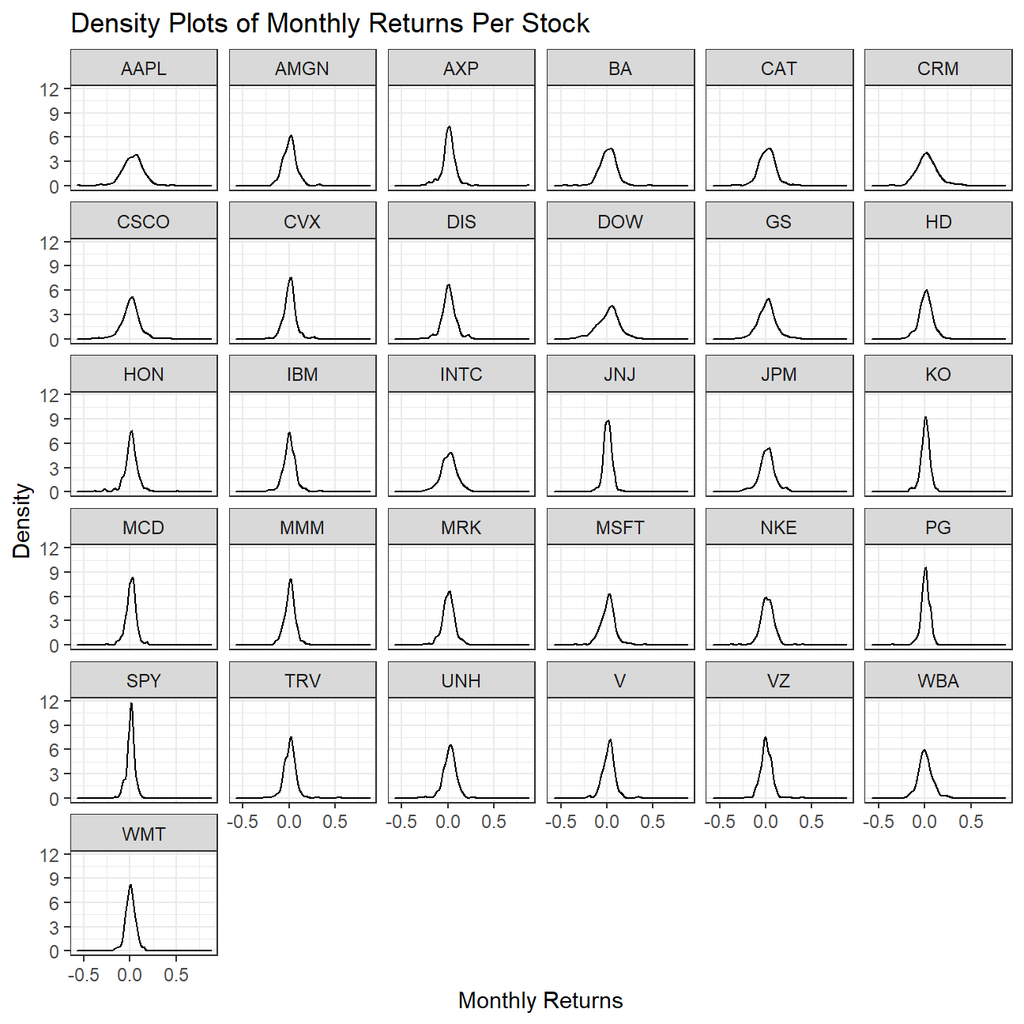

```r
myStocks_returns_monthly %>%
  #Plot a density graph for each stock
  ggplot(aes(x = monthly_returns)) +
  geom_density()+
  theme_bw()+
  labs(
    title = "Density Plots of Monthly Returns Per Stock",
    x = 'Monthly Returns',
    y = 'Density'
  )+
  facet_wrap(vars(symbol))+
  NULL
```

What can you infer from this plot? Which stock is the riskiest? The least risky?

> TYPE YOUR ANSWER AFTER (AND OUTSIDE!) THIS BLOCKQUOTE.

Finally, make a plot that shows the expected monthly return (mean) of a stock on the Y axis and the risk (standard deviation) in the X-axis. Please use `ggrepel::geom_text_repel()` to label each stock

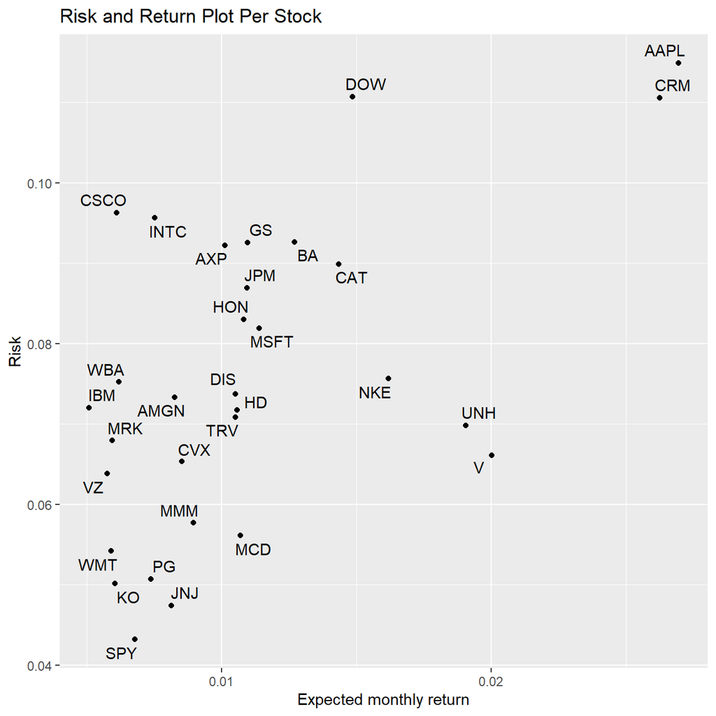

```r
myStocks_returns_monthly %>%
group_by(symbol) %>%
summarize(mean=mean(monthly_returns),
        sd=sd(monthly_returns)) %>%
  ggplot(aes(x = mean,y = sd)) +
  geom_point() +
  ggrepel::geom_text_repel(aes(label = symbol)) +
  labs(
    title = "Risk and Return Plot Per Stock",
    x = 'Expected monthly return',
    y = 'Risk'
  ) +
  NULL
```

What can you infer from this plot? Are there any stocks which, while being riskier, do not have a higher expected return?

> TYPE YOUR ANSWER AFTER (AND OUTSIDE!) THIS BLOCKQUOTE.

CSCO and INTC have high risks with low returns. There is a positive relationship between risk and return for most of the stocks. However, there are exceptions. V, UNH and NKE have relatively low risk with high returns. And it is probably because that people’s daily life heavily relies on Visa(V). Healthcare(UNH) has been a necessity and there has always been a huge demand for Nike(NKE) products.

# 4 Is inflation transitory?

> You may find useful the material on [downloading economic data from the FRED](https://mfa2022.netlify.app/reference/finance_data/#data-from-the-federal-reserve-economic-data-with-tidyquant).

A recent study by the Bank for International Settlements (BIS) claimed that the [Current Inflation Spike Is Just Transitory](https://www.bloomberg.com/news/articles/2021-09-20/current-inflation-spike-is-just-transitory-new-bis-study-argues). As the article says,

> The surge in inflation seen across major economies is probably short lived because it’s confined to just a few sectors of the economy, according to the Bank for International Settlements.

> New research by the BIS’s Claudio Borio, Piti Disyatat, Egon Zakrajsek and Dora Xia adds to one of the hottest debates in economics – how long the current surge in consumer prices will last. Both Federal Reserve Chair Jerome Powell and his euro-area counterpart Christine Lagarde have said the pickup is probably transitory, despite a snarled global supply chain and a spike in energy prices.

You have to download data for CPI and the 10 year bill and produce the following graph

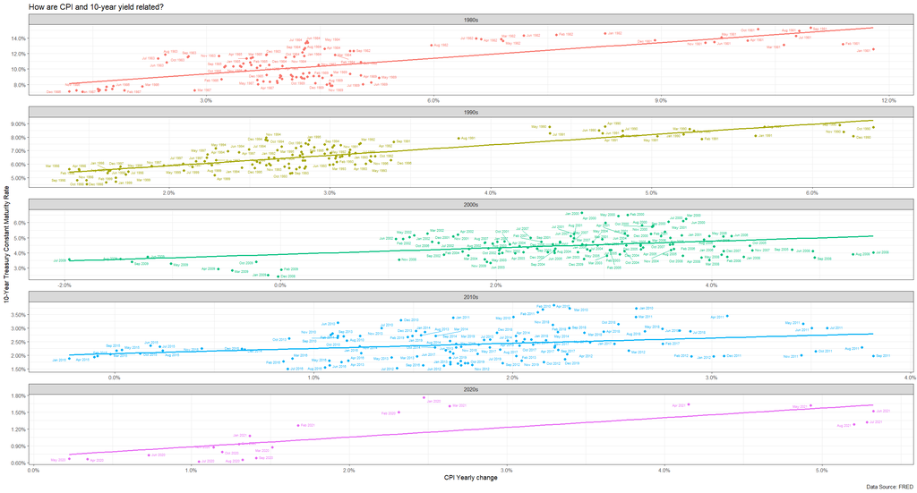

The relevant indicators from FRED are:

- [Consumer Price Index for All Urban Consumers: All Items in U.S. City Average](https://fred.stlouisfed.org/series/CPIAUCSL)
- [10-Year Treasury Constant Maturity Rate](https://fred.stlouisfed.org/series/GS10)

```r
cpi  <-   tq_get("CPIAUCSL", get = "economic.data",
                       from = "1980-01-01") %>%
  rename(cpi = symbol,  # FRED data is given as 'symbol' and 'price'
         rate = price) %>% # we rename them to what they really are, e.g., cpi and rate

  # calculate yearly change in CPI by dividing current month by same month a year (or 12 months) earlier, minus 1
  mutate(cpi_yoy_change = rate/lag(rate, 12) - 1)

ten_year_monthly  <-   tq_get("GS10", get = "economic.data",
                       from = "1980-01-01") %>%
  rename(ten_year = symbol,
         yield = price) %>%
  mutate(yield = yield / 100) # original data is not given as, e.g., 0.05, but rather 5, for five percent

# we have the two dataframes-- we now need to join them, and we will use left_join()
# base R has a function merge() that does the same, but it's slow, so please don't use it

mydata <-
  cpi %>%
  left_join(ten_year_monthly, by="date") %>%
  mutate(
    year = year(date), # using lubridate::year() to generate a new column with just the year
    month = month(date, label = TRUE),
    decade=case_when(
      year %in% 1980:1989 ~ "1980s",
      year %in% 1990:1999 ~ "1990s",
      year %in% 2000:2009 ~ "2000s",
      year %in% 2010:2019 ~ "2010s",
      TRUE ~ "2020s"
      )
  )
```

### 4.0.1 Plotting the 10 year bill and CPI data to display their relationship

[figure not shown]

```r
plot1 <- ggplot(data = mydata, mapping = aes(x = cpi_yoy_change, y = yield, color = decade))+
  geom_point()+                             #plot 10 year tbill rates against CPI data
  geom_smooth(method = "lm", se = FALSE)+   #plot a line of best fit
  geom_text(aes(label = date), size = 2.5)+
  facet_wrap(~decade, scales = "free", ncol = 1)+     #wrap by decade
  ggrepel::geom_text_repel(data = mydata, aes(label=""))+
  scale_y_continuous(labels = scales::percent)+
  scale_x_continuous(labels = scales::percent)+     #edit axis scales
  guides(color=FALSE) +
  labs(
    title = "How are CPI and 10-year yield related?",
    x = "CPI Yearly change",
    y = "10-Year Treasury Constant Maturity Rate"
  )+
  theme_bw()+
  NULL

plot1 <- plot1 + theme(                                #edit axis headings
axis.title.y = element_text(face="bold"),
axis.title.x = element_text(face="bold")
)+
  NULL

plot(plot1)
```

# 5 Challenge 1: Replicating a chart

#The purpose of this exercise is to reproduce a plot using your `dplyr` and `ggplot2` skills. Read the article [The Racial Factor: There’s 77 Counties Which Are Deep Blue But Also Low-Vaxx. Guess What They Have In Common?](https://acasignups.net/21/07/18/racial-factor-theres-77-counties-which-are-deep-blue-also-low-vaxx-guess-what-they-have) and have a look at the attached figure.

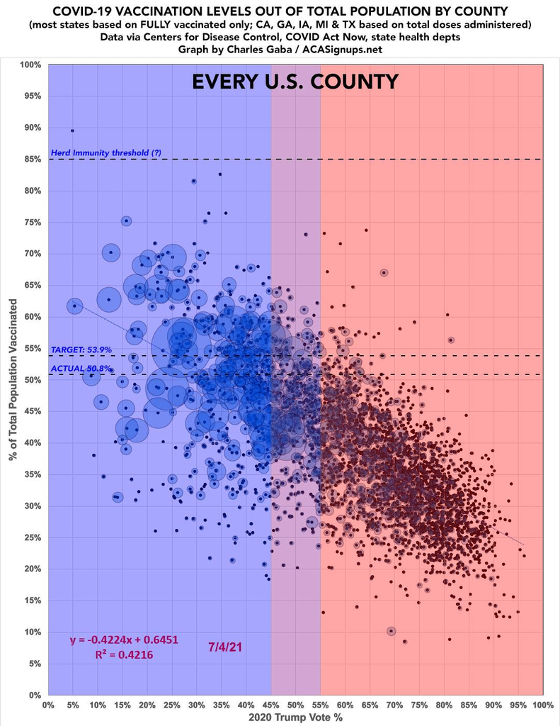

You dont have to worry about the blue-red backgound and don’t worry about replicating it exactly, try and see how far you can get. You’re encouraged to work together if you want to and exchange tips/tricks you figured out– and even though the figure in the original article is from early July 2021, you can use the most recent data.

Some hints to get you started:

1. To get vaccination by county, we will use [data from the CDC](https://data.cdc.gov/Vaccinations/COVID-19-Vaccinations-in-the-United-States-County/8xkx-amqh)
2. You need to get [County Presidential Election Returns 2000-2020](https://dataverse.harvard.edu/dataset.xhtml?persistentId=doi:10.7910/DVN/VOQCHQ)
3. Finally, you also need an estimate of the [population of each county](https://www.ers.usda.gov/webdocs/DataFiles/48747/PopulationEstimates.csv?v=2232)

You may find counties that as of September 2021 have 0% vaccination; don’t discard them immediately, try to find out why you have zeros!

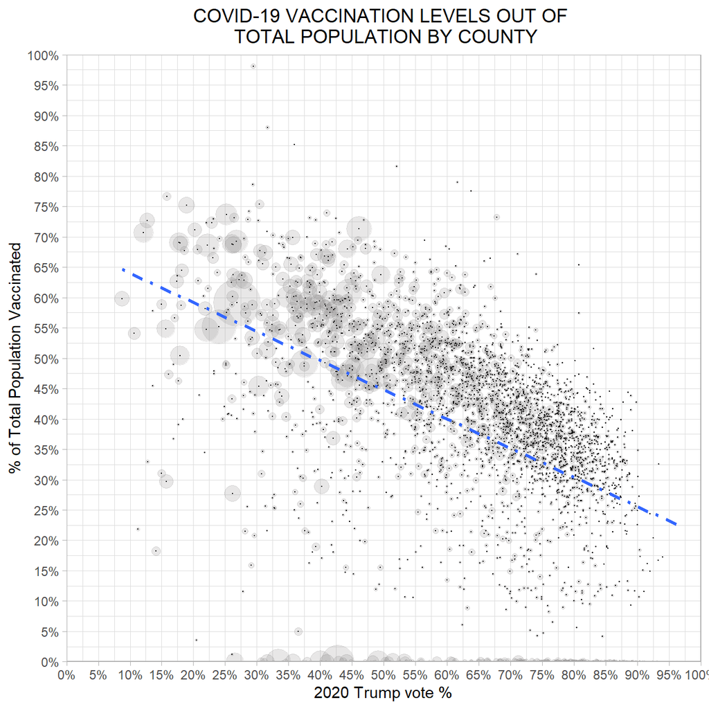

```r
trump_results <- election2020_results %>%
  select(3, 4, 5, 7, 9 ,10) %>%
  filter(candidate == "DONALD J TRUMP")

filtered_vaccinations <- vaccinations %>%
  filter(date == "09/23/2021") %>%
  select(1, 2, 4, 5, 7)

vaccinations_pop <- left_join(filtered_vaccinations, population)

trump_vaccinations_pop <- left_join(trump_results, vaccinations_pop)

county_data <- trump_vaccinations_pop %>%
  group_by(fips) %>%
  summarise(county = county_name,
            candidatevotes = sum(candidatevotes, na.rm = TRUE),
            totalvotes = totalvotes, na.rm = TRUE,
            vaccination_number = series_complete_yes, na.rm = TRUE,
            totalpop = pop_estimate_2019, na.rm = TRUE)

county_data2 <- unique(county_data)

final_county_data <- county_data2 %>%
  mutate(trump_vote_perc = (candidatevotes / totalvotes) * 100,
         vaccination_perc = (vaccination_number / totalpop) * 100) %>%
  na.omit

ggplot(final_county_data, aes(x = trump_vote_perc, y = vaccination_perc))+
  geom_point(alpha = 0.2, color = "snow4", aes(size = totalpop))+
  scale_size(range = c(.1, 15), name = "Population (M)")+
  geom_point(size= 0.1)+
  geom_smooth(method = "lm",
              se = FALSE,
              lty=10,
              lwd = 1) +
  xlab("2020 Trump vote %")+
  ylab("% of Total Population Vaccinated")+
  labs(title = "COVID-19 VACCINATION LEVELS OUT OF \n TOTAL POPULATION BY COUNTY") +
  theme_light()+
  theme(plot.title = element_text(hjust=0.5)) +
  scale_y_continuous(expand = c(0,0), labels = function(y) paste0(y, "%"), breaks = scales::pretty_breaks(n=20), limits = c(0,100))+
  scale_x_continuous(expand = c(0,0), labels = function(x) paste0(x, "%"), breaks = scales::pretty_breaks(n=20), limits = c(0,100))+
  theme(legend.position = "none")
```